# R-Lunch: Linear Mixed Models

M.-O. Boldi

03/03/2020

# A random effect linear model

During an afterwork party, you have been clever enough to be involved in the study of the rotational speed of eggs. This fascinating experience is performed by four top ranked scientists (A, B, C, D), including you, on a wooden table. An initial speed of 3 rps (3 round per second) is given to the egg. The speed is measured after 10 seconds. The results are given below[^1].

```r
dat1
```

```
##    ID Speed
## 1   A  0.76
## 2   A  2.90
## 3   A  1.10
## 4   A  1.20
## 5   A  0.40
## 6   B  1.60
## 7   B  1.60
## 8   B  1.40
## 9   B  1.70
## 10  B  2.10
## 11  C  1.30
## 12  C  0.89
## 13  C  1.30
## 14  C  1.80
## 15  C  1.70
## 16  D  1.30
## 17  D  2.60
## 18  D  2.00
## 19  D  2.20
## 20  D  1.60
```

The model of this experience is
$$y_{ij} = m + s_i + e_{ij}, \quad i=1,\ldots,4, \; j=1,\ldots,5.$$
There, $m$ is the average rotational speed of an egg, and $s_i$ is the effect of subject $i$ (scientist). There are 5 replicates per subject.

Since the subjects are not of interest – we do not want to compare $A$ to $B$ for example – but since we need to take their effect into account, they are fitted as random effects in the model. For linear models, normal random effects and residuals are assumed
$$s_i \stackrel{i.i.d.}{\sim} N(0, \sigma_s^2), \quad e_{ij} \stackrel{i.i.d.}{\sim} N(0, \sigma^2).$$
The model is fitted to the data using package lme4 and lmerTest[^2].

```r
require(lme4)
require(lmerTest)
```

```r
mod <- lmer(Speed ~ 1 + (1|ID), data=dat1)
summary(mod)
## Linear mixed model fit by REML. t-tests use Satterthwaite's method [
## lmerModLmerTest]
## Formula: Speed ~ 1 + (1 | ID)
##    Data: dat1
##
## REML criterion at convergence: 37.5
##
## Scaled residuals:
##      Min       1Q   Median       3Q      Max
## -1.87896 -0.54001 -0.04338  0.48649  2.37048
##
## Random effects:
##  Groups   Name        Variance Std.Dev.
##  ID       (Intercept) 0.0199   0.1410
##  Residual             0.3461   0.5883
## Number of obs: 20, groups:  ID, 4
##
## Fixed effects:
##             Estimate Std. Error     df t value Pr(>|t|)
## (Intercept)   1.5725     0.1493 3.0000   10.54  0.00183 **
## ---
## Signif. codes:  0 '***' 0.001 '**' 0.01 '*' 0.05 '.' 0.1 ' ' 1
```

Note the synthax: “1 + (1 | ID)” is readed one intercept ($m$) plus one intercept per ID ($s_i$).

# A mixed effects linear model

As the evening goes on, our brave researchers have the idea to compare raw eggs to cooked ones. A and B receive 10 raw eggs, C and D receive 10 cooked eggs. The Type (raw or cooked) is the fixed effect. The results are

```r
dat2
```

```
##    ID   Type Speed
## 1   A    Raw  0.76
## 2   A    Raw  2.90
## 3   A    Raw  1.10
## 4   A    Raw  1.20
## 5   A    Raw  0.40
## 6   B    Raw  1.60
## 7   B    Raw  1.60
## 8   B    Raw  1.40
## 9   B    Raw  1.70
## 10  B    Raw  2.10
## 11  C Cooked  1.70
## 12  C Cooked  1.30
## 13  C Cooked  1.70
## 14  C Cooked  2.20
## 15  C Cooked  2.10
## 16  D Cooked  1.70
## 17  D Cooked  3.00
## 18  D Cooked  2.40
## 19  D Cooked  2.60
## 20  D Cooked  2.00
```

The model can be fitted using

```r
mod2 <- lmer(Speed ~ Type + (1|ID), data=dat2)
summary(mod2)
## Linear mixed model fit by REML. t-tests use Satterthwaite's method [
## lmerModLmerTest]
## Formula: Speed ~ Type + (1 | ID)
##    Data: dat2
##
## REML criterion at convergence: 37.6
##
## Scaled residuals:
##      Min       1Q   Median       3Q      Max
## -1.69297 -0.46098 -0.09683  0.38528  2.56035
##
## Random effects:
##  Groups   Name        Variance Std.Dev.
##  ID       (Intercept) 0.04542  0.2131
##  Residual             0.34548  0.5878
## Number of obs: 20, groups:  ID, 4
##
## Fixed effects:
##             Estimate Std. Error      df t value Pr(>|t|)
## (Intercept)   2.0700     0.2393  2.0000   8.651   0.0131 *
## TypeRaw      -0.5940     0.3384  2.0000  -1.755   0.2213
## ---
## Signif. codes:  0 '***' 0.001 '**' 0.01 '*' 0.05 '.' 0.1 ' ' 1
##
## Correlation of Fixed Effects:
##         (Intr)
## TypeRaw -0.707
```

The significance of the Type contrast can already be seen from the t-test. If ANOVA F-test (type III) is needed then use

```r
anova(mod2)
## Type III Analysis of Variance Table with Satterthwaite's method
##      Sum Sq Mean Sq NumDF DenDF F value Pr(>F)
## Type 1.0645  1.0645     1     2  3.0811 0.2213
```

It is a so-called “between effect” because each subject do not receive all the modalities of the fixed effect Type.

# Mixed effects linear model: within effect

Suppose that the design is that each subject receives 2 raw and 2 cooked eggs (only 16 observations). Then Type is a within-effect (a “within-subject” effect) since each subject receives all the modalities of the fixed effect.

```r
dat3
```

```
##    ID   Type Speed
## 1   A    Raw  0.76
## 2   A Cooked  3.00
## 3   A    Raw  1.10
## 4   A Cooked  1.60
## 5   B    Raw  0.40
## 6   B Cooked  2.00
## 7   B    Raw  1.60
## 8   B Cooked  1.80
## 9   C    Raw  1.70
## 10  C Cooked  2.50
## 11  C    Raw  1.30
## 12  C Cooked  1.30
## 13  D    Raw  1.30
## 14  D Cooked  2.20
## 15  D    Raw  1.70
## 16  D Cooked  1.70
```

The previous analysis gives:

```r
mod3 <- lmer(Speed ~ Type + (1|ID), data=dat3)
summary(mod3)
## Linear mixed model fit by REML. t-tests use Satterthwaite's method [
## lmerModLmerTest]
## Formula: Speed ~ Type + (1 | ID)
##    Data: dat3
##
## REML criterion at convergence: 24.8
##
## Scaled residuals:
##      Min       1Q   Median       3Q      Max
## -1.64540 -0.66705  0.05435  0.77576  1.95175
##
## Random effects:
##  Groups   Name        Variance Std.Dev.
##  ID       (Intercept) 0.000    0.000
##  Residual             0.256    0.506
## Number of obs: 16, groups:  ID, 4
##
## Fixed effects:
##             Estimate Std. Error      df t value Pr(>|t|)
## (Intercept)   2.0125     0.1789 14.0000  11.250 2.13e-08 ***
## TypeRaw      -0.7800     0.2530 14.0000  -3.083   0.0081 **
## ---
## Signif. codes:  0 '***' 0.001 '**' 0.01 '*' 0.05 '.' 0.1 ' ' 1
##
## Correlation of Fixed Effects:
##         (Intr)
## TypeRaw -0.707
## convergence code: 0
## boundary (singular) fit: see ?isSingular
anova(mod3)
## Type III Analysis of Variance Table with Satterthwaite's method
##      Sum Sq Mean Sq NumDF DenDF F value   Pr(>F)
## Type 2.4336  2.4336     1    14  9.5065 0.008097 **
## ---
## Signif. codes:  0 '***' 0.001 '**' 0.01 '*' 0.05 '.' 0.1 ' ' 1
```

# Test of the random effects

If you want to test the random effect itself (here the random intercept per ID), use function **ranova** or **rand**.

```r
mod3 <- lmer(Speed ~ Type + (1|ID), data=dat3)
rand(mod3)
## ANOVA-like table for random-effects: Single term deletions
##
## Model:
## Speed ~ Type + (1 | ID)
##          npar  logLik    AIC LRT Df Pr(>Chisq)
## <none>      4 -12.406 32.813
## (1 | ID)    3 -12.406 30.813   0  1          1
```

Technically, it performs a (REML)-likelihood ratio test (“REML-RT”).

# Mixed effects linear model: crossed effect

“The table!! It changes everything…” shouts your Nobelizable colleague. Of course the table can change everything. Here goes your team, assigning 5 tables and spinning raw and cooked eggs all around the pub. The results are below.

```r
dat4
```

```
##    ID Table   Type Speed
## 1   A    T1    Raw  1.00
## 2   A    T1 Cooked  1.30
## 3   A    T2    Raw  2.40
## 4   A    T2 Cooked  2.90
## 5   A    T3    Raw  1.30
## 6   A    T3 Cooked  1.70
## 7   A    T4    Raw  1.20
## 8   A    T4 Cooked  1.80
## 9   A    T5    Raw  0.78
## 10  A    T5 Cooked  1.20
## 11  B    T1    Raw  0.97
## 12  B    T1 Cooked  1.40
## 13  B    T2    Raw  2.70
## 14  B    T2 Cooked  3.00
```

[output cut: 26 more lines]

The table is a random effect because tables are taken at random, and are not of interest[^3]. The two random effects are crossed and independent.

```r
mod4 <- lmer(Speed ~ Type + (1|Table) + (1|ID), data=dat4)
summary(mod4)
## Linear mixed model fit by REML. t-tests use Satterthwaite's method [
## lmerModLmerTest]
## Formula: Speed ~ Type + (1 | Table) + (1 | ID)
##    Data: dat4
##
## REML criterion at convergence: -48.2
##
## Scaled residuals:
##      Min       1Q   Median       3Q      Max
## -1.85131 -0.70411  0.08155  0.45416  1.94503
##
## Random effects:
##  Groups   Name        Variance  Std.Dev.
##  Table    (Intercept) 4.813e-01 0.693746
##  ID       (Intercept) 3.449e-05 0.005873
##  Residual             7.239e-03 0.085082
## Number of obs: 40, groups:  Table, 5; ID, 4
##
## Fixed effects:
##             Estimate Std. Error       df t value Pr(>|t|)
## (Intercept)  1.77000    0.31085  4.01565   5.694  0.00464 **
## TypeRaw     -0.42300    0.02691 31.00240 -15.722 2.54e-16 ***
## ---
## Signif. codes:  0 '***' 0.001 '**' 0.01 '*' 0.05 '.' 0.1 ' ' 1
##
## Correlation of Fixed Effects:
##         (Intr)
## TypeRaw -0.043
anova(mod4)
## Type III Analysis of Variance Table with Satterthwaite's method
##      Sum Sq Mean Sq NumDF  DenDF F value    Pr(>F)
## Type 1.7893  1.7893     1 31.002  247.17 2.543e-16 ***
## ---
## Signif. codes:  0 '***' 0.001 '**' 0.01 '*' 0.05 '.' 0.1 ' ' 1
```

It reads as “one intercept + Type effect + one intercept per Table + one intercept per ID”.

The test above is for the fixed effect. Testing the random effects can be done with a REM-LRT:

```r
rand(mod4)
## ANOVA-like table for random-effects: Single term deletions
##
## Model:
## Speed ~ Type + (1 | Table) + (1 | ID)
##             npar  logLik     AIC     LRT Df Pr(>Chisq)
## <none>         5  24.095 -38.191
## (1 | Table)    4 -40.093  88.186 128.377  1     <2e-16 ***
## (1 | ID)       4  24.094 -40.188   0.003  1     0.9564
## ---
## Signif. codes:  0 '***' 0.001 '**' 0.01 '*' 0.05 '.' 0.1 ' ' 1
```

Note: F-test and specially the Likelihood Ratio Test for mixed linear models must be used with care. The F-tests can be exact (even for random effect testing). The REML-RT is always approximate and can be severly biased in some cases.

# Mixed effects linear model: nested effects

Forget about the tables and the egg type for a moment. Assume that, for the first experience, each researcher receive two (raw) eggs and is to make three replicates of the measure. The data would look like

```r
dat5
```

```
##    ID Egg Speed
## 1   A  E1  1.20
## 2   A  E1  1.30
## 3   A  E1  1.30
## 4   A  E2  2.80
## 5   A  E2  3.00
## 6   A  E2  2.90
## 7   B  E1  1.80
## 8   B  E1  1.70
## 9   B  E1  1.80
## 10  B  E2  2.00
## 11  B  E2  1.90
## 12  B  E2  1.70
## 13  C  E1  0.77
## 14  C  E1  0.84
## 15  C  E1  0.85
## 16  C  E2  1.70
## 17  C  E2  1.70
## 18  C  E2  1.80
## 19  D  E1  1.60
## 20  D  E1  1.80
## 21  D  E1  1.50
## 22  D  E2  1.30
## 23  D  E2  1.40
## 24  D  E2  1.30
```

Since Egg E1 for researcher A is not the same as Egg E1 for researcher B (and so on), the Egg effect (which is random) is called nested (within effect ID). This design is noted as below. Produce the summary and the test of the random effect.

```r
mod5 <- lmer(Speed ~ 1 + (1 | ID/Egg), data=dat5)
```

It reads as “one intercept + one intercept per ID + one intercept per Egg within ID”.

Note that, there is nothing in the data which indicates whether the effect is nested or not. If the egg would have been the same among researchers, then the two effects would have been crossed like for Table.

A nested effect can be seen as an **interaction** between two factors: the Egg effect (E1, E2) is changing from one ID to another (A, B, C, D).

Calling (1 | ID/Egg) in lmer includes both the effect ID and the interaction Egg:ID. This can be seen on summary(mod5). However, calling rand(mod5) only produce one global test. Suppose you would like to separate the main effect ID from the interaction Egg:ID, just call

```r
mod5 <- lmer(Speed ~ 1 + (1 | ID) + (1 | Egg:ID), data=dat5)
```

You can check that the summary is the same. Function rand will separate the two tests. You can also use this if you want to include only the Egg effect without the ID effect (like it could be the case here).

# Mixed effects linear model: random slope

Let us leave our brave researchers and focus on the famous data set Orthodont from Package **nlme**. See the help for its description.

```r
require(nlme)
head(Orthodont)
## Grouped Data: distance ~ age | Subject
##   distance age Subject  Sex
## 1     26.0   8     M01 Male
## 2     25.0  10     M01 Male
## 3     29.0  12     M01 Male
## 4     31.0  14     M01 Male
## 5     21.5   8     M02 Male
## 6     22.5  10     M02 Male
```

We see that object Orthodont is a groupedData object (defined in package nlme). In particular it has a grouping formula associated to it.

To represent the data, we can use the general function xyplot from package lattice, or function plot from package nlme (method nfnGroupedData) on the groupedData object Orthodont. The results are quite similar.

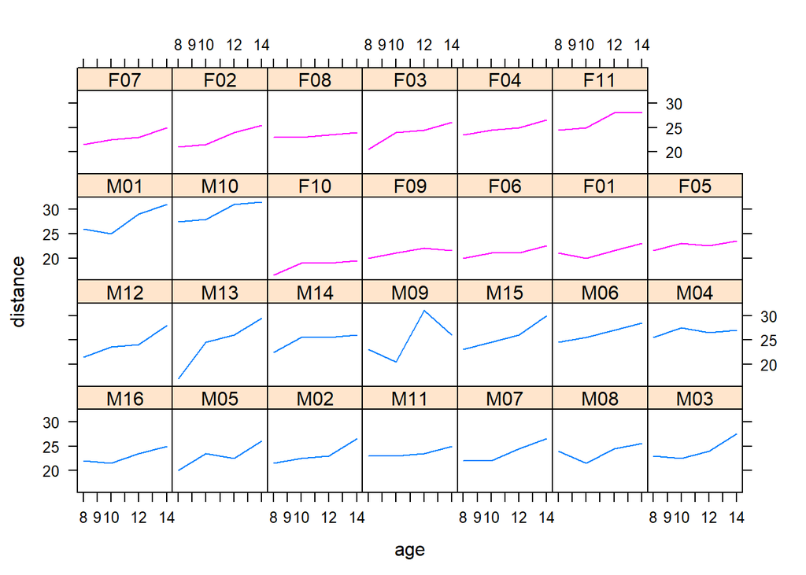

```r
require(lattice)
xyplot(distance ~ age | Subject, data=Orthodont, type='l', group=Sex)
```

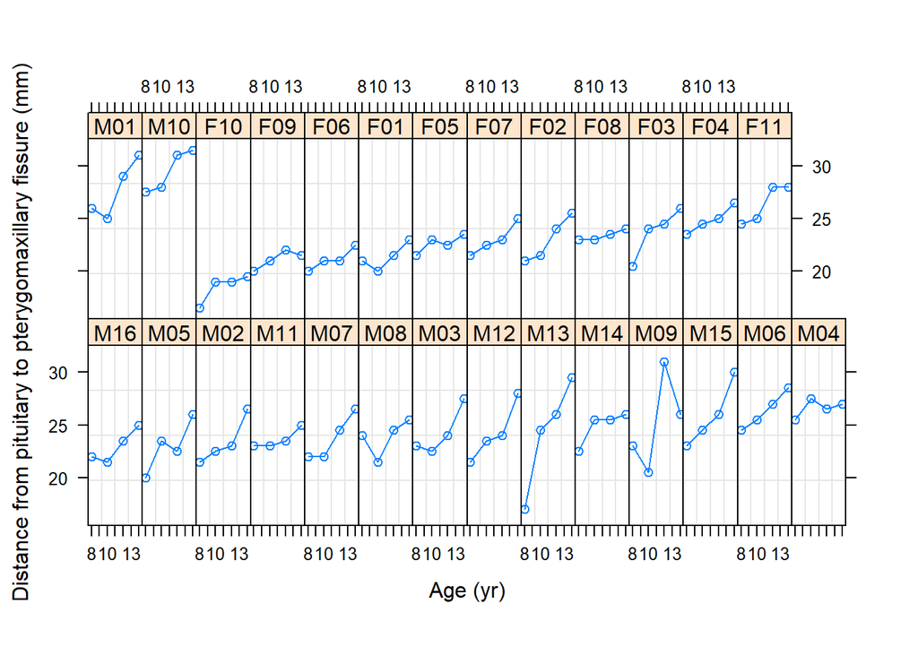

```r
plot(Orthodont)
```

If you want to plot grouping by Sex, it can be specified by

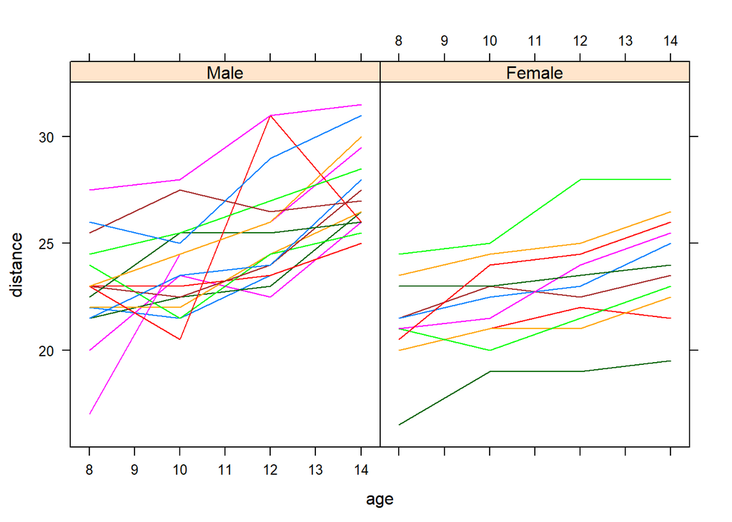

```r
xyplot(distance ~ age | Sex, data=Orthodont, type='l', group=Subject)
```

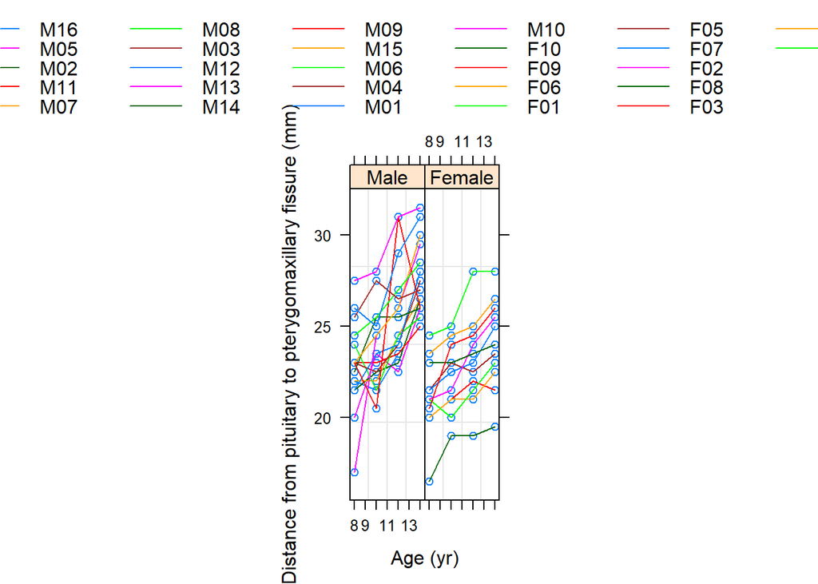

```r
plot(Orthodont, outer=~Sex)
```

Back to the analysis, we see that the slope (coefficient associated to age in a regression) varies

1. Per Sex: interaction “age:Sex”; the interaction between fixed effects.
2. Per Subject: interaction “age:Subject”. This is an interaction between a fixed effect and a random effect. With a slope, it is called a **random slope**.

First let’s ignore the Sex effect to simplify and focus on the Male data. To fit the model, use

```r
mod6 <- lmer(distance ~ age + (age|Subject), data=Orthodont, subset=(Sex=="Male"))
summary(mod6)
## Linear mixed model fit by REML. t-tests use Satterthwaite's method [
## lmerModLmerTest]
## Formula: distance ~ age + (age | Subject)
##    Data: Orthodont
##  Subset: (Sex == "Male")
##
## REML criterion at convergence: 273.1
##
## Scaled residuals:
##      Min       1Q   Median       3Q      Max
## -2.66110 -0.59610  0.01887  0.57401  3.15498
##
## Random effects:
##  Groups   Name        Variance Std.Dev. Corr
##  Subject  (Intercept) 7.01455  2.649
##           age         0.03496  0.187    -0.79
##  Residual             2.59426  1.611
## Number of obs: 64, groups:  Subject, 16
##
## Fixed effects:
##             Estimate Std. Error      df t value Pr(>|t|)
## (Intercept)  16.3406     1.2083 14.9941  13.524 8.34e-10 ***
## age           0.7844     0.1014 14.9419   7.732 1.34e-06 ***
## ---
## Signif. codes:  0 '***' 0.001 '**' 0.01 '*' 0.05 '.' 0.1 ' ' 1
##
## Correlation of Fixed Effects:
##     (Intr)
## age -0.926
## convergence code: 0
## Model failed to converge with max|grad| = 0.0320902 (tol = 0.002, component 1)
```

The formula is read as “age” is the fixed effect (like in a linear regression), and “(age|Subject)” means “there is one age coefficient per subject”. The corresponding mathematical model is
$$y_{ij} = \alpha + a_i + (\beta+b_i) t_{j} + e_{ij}$$
where

1. $\alpha$ is the intercept and $\beta$ is the average slope. $a_i$ is the intercept gap of subject $i$ (i.e. $\alpha+a_i$ is the intercept of subject $i$).
2. $b_i$ is the slope gap of subject $i$ (i.e. $\beta + b_i$ is the slope of subject $i$).
3. $t_j$ is the age measured at occasion $j$
4. $e_{ij}$ is the residual.

The distributional hypotheses are
$$a_i \stackrel{i.i.d.}{\sim} N(0,\sigma_a^2), \quad
b_i \stackrel{i.i.d.}{\sim} N(0,\sigma_b^2), \quad
cor(a_i, b_i) = \rho, \quad
e_{ij} \stackrel{i.i.d.}{\sim} N(0,\sigma^2)$$
All these parameter estimates can be identified in **summary(mod6)**.

In particular, you’ll see that $\hat{\rho}=-0.79$. How can this be interpreted? In fact, by defaut, lmer assumes a correlation between random intercept and random slope. A strong negative correlation like this means that when $a_i$ is large, then $b_i$ is small.

Let’s admit that often it is of low interest, and probably with risks of overfitting. It is possible to force $\rho=0$ using

```r
mod7 <- lmer(distance ~ age + (age || Subject), data=Orthodont, subset=(Sex=="Male"))
```

Note that the random intercept is implicit in the formula, i.e. we did not need to write “(1+age)”. Like for fixed effect, if we want to force the random intercept out, we need to expicitla write

```r
mod8 <- lmer(distance ~ age + (0 + age | Subject), data=Orthodont, subset=(Sex=="Male"))
```

This explains why another way to have independent random intercept and slopes is to write (equiv. to mod7 above)

```r
mod7 <- lmer(distance ~ age + (1|Subject) + (0+age | Subject), data=Orthodont, subset=(Sex=="Male"))
```

# Non-linear mixed models

Consider the data set Orange of the trunk circonference of 5 orange trees, measured at several occasions.

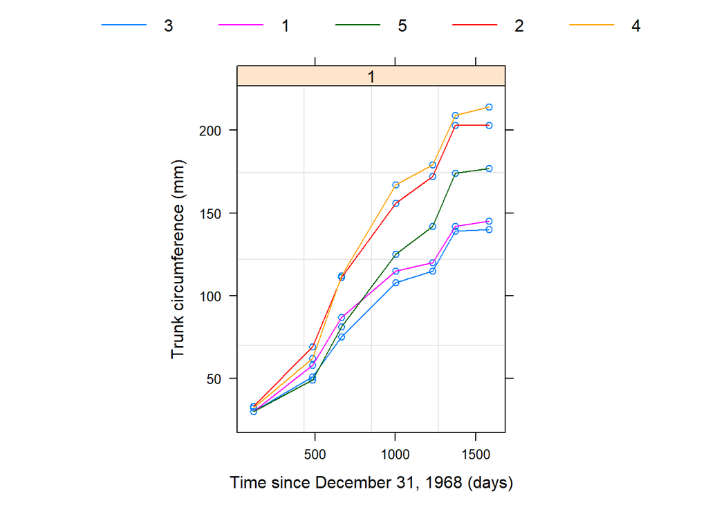

```r
head(Orange)
## Grouped Data: circumference ~ age | Tree
##   Tree  age circumference
## 1    1  118            30
## 2    1  484            58
## 3    1  664            87
## 4    1 1004           115
## 5    1 1231           120
## 6    1 1372           142
plot(Orange, outer=~1)
```

The circumference $g$ is modeled as a function of the tree age $x$ by
$$g(x; \phi_a, \phi_h, \phi_s) = \frac{\phi_a}{1+\exp\{-(x-\phi_h)/\phi_s\}}.$$
The parameters (to be estimated) are

1. $\phi_a$, the asymptotic circumference,
2. $\phi_h$, the age at which the tree attains half of its asymptotic circumference,
3. $\phi_s$, the growth scale.

This function is already implemented in lme4 and named SSlogis.

Without taking the tree effect into account, one could fit a non-linear model

```r
mod8 <- nls(circumference ~ SSlogis(age, phia, phih, phis), data=Orange, start=c(phia=170, phih=700, phis=500))
summary(mod8)
```

```
##
## Formula: circumference ~ SSlogis(age, phia, phih, phis)
##
## Parameters:
##      Estimate Std. Error t value Pr(>|t|)
## phia   192.69      20.24   9.518 7.48e-11 ***
## phih   728.75     107.30   6.792 1.12e-07 ***
## phis   353.53      81.47   4.339 0.000134 ***
## ---
## Signif. codes:  0 '***' 0.001 '**' 0.01 '*' 0.05 '.' 0.1 ' ' 1
##
## Residual standard error: 23.37 on 32 degrees of freedom
##
## Number of iterations to convergence: 5
## Achieved convergence tolerance: 4.386e-06
```

This correspond to the average fit

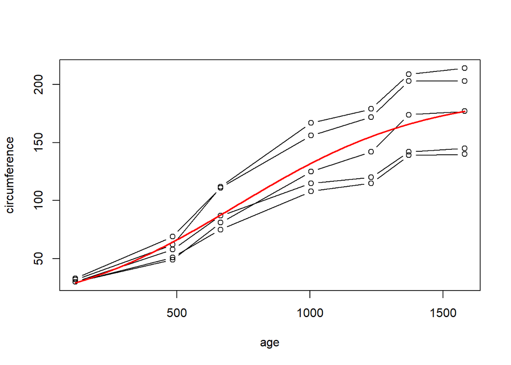

To account for the subject (tree) effect, we have to specify a random structure. Again, the key is to define when a parameter varies per tree. In the code below, parameters $\phi_a$ and $\phi_h$ varies with trees, and $\phi_s$ is common to all tree:

```r
mod9 <- nlmer(circumference ~ SSlogis(age, phia, phih, phis) ~ (phia|Tree) + (phih|Tree),
             Orange, start = c(phia = 200, phih = 725, phis = 350))
summary(mod9)
## Nonlinear mixed model fit by maximum likelihood  ['nlmerMod']
## Formula: circumference ~ SSlogis(age, phia, phih, phis) ~ (phia | Tree) +
##     (phih | Tree)
##    Data: Orange
##
##      AIC      BIC   logLik deviance df.resid
##    275.1    284.5   -131.6    263.1       29
##
## Scaled residuals:
##     Min      1Q  Median      3Q     Max
## -1.9170 -0.5421  0.1755  0.7116  1.6820
##
## Random effects:
##  Groups   Name Variance  Std.Dev.
##  Tree     phia 1.001e+03 31.646296
##  Tree.1   phih 6.568e-05  0.008105
##  Residual      6.151e+01  7.843012
## Number of obs: 35, groups:  Tree, 5
##
## Fixed effects:
##      Estimate Std. Error t value
## phia   192.05      15.58   12.32
## phih   727.91      34.44   21.14
## phis   348.07      26.31   13.23
##
## Correlation of Fixed Effects:
##      phia  phih
## phih 0.384
## phis 0.362 0.762
```

This corresponds to the model
$$y_{ij} = g(x_j; \phi_{ai}, \phi_{hi}, \phi_s) + \epsilon_{ij}$$
where
$$\phi_{ai} \sim N(0,\sigma_a^2), \quad
\phi_{hi} \sim N(0,\sigma_h^2), \quad
\epsilon_{ij} \sim N(0,\sigma^2)$$
The fact that $\phi_s$ is not random is purely for illustration purposes. If we extract the predictions of the random components (see later), one obtains the predictions

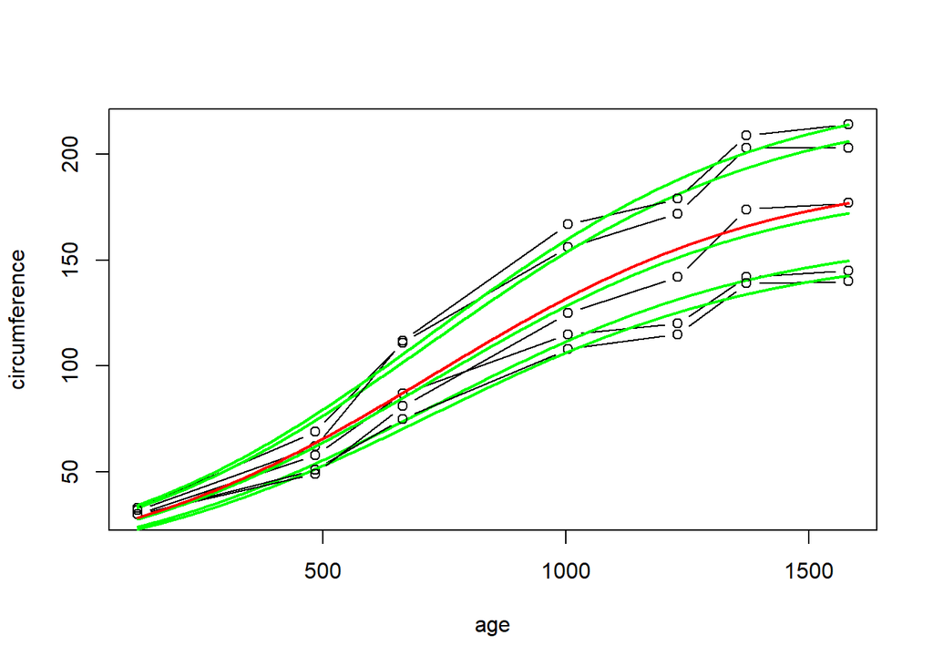

This illustrates how the variation of the parameters is taken into account by the model.

Remark: the SSlogis function is built-in. However, one can define its own function. However, to be used with nlmer, it must provides also the gradient of the function in a matrix attribute.

# Mixed models: Prediction

## Prediction of random effects

In the previous example, we have extracted the prediction of the random components of the model. For a linear model, the component predictions can be extracted using function ranef

```r
ranef(mod)
```

```
## $ID
##   (Intercept)
## A -0.06708518
## B  0.02399886
## C -0.03895629
## D  0.08204261
##
## with conditional variances for "ID"
```

The prediction is the conditional expectation of the random effect given the data $E(U|Y=y)$ in a generic mixed linear model
$$Y = X\beta + ZU + \epsilon.$$
In the case of linear mixed models, the conditional distribution of $U|Y=y$ is Gaussian and the prediction can be obtained by matrix straightforward multplications. In the case of non-linear mixed models (Orange tree example), the distribution of $Y$ is not Gaussian anymore. The prediction is not more approximate.

Exercise: compute (extract using R) the predictions of the random components of all the previous models. Have a more detailed look at the crossed effects and the hierarchical models, and try to understand the structure of the random components by comparing them.

## Predictions of the response

Considering model mod. The predictions are the sum of the estimated fixed effects and the predicted random effects. Compare

```r
coef(summary(mod))[1]+ ranef(mod)$ID
predict(mod)
```

For the prediction of a new subject (a new researcher), the prediction of the random effect is 0. Compare

```r
coef(summary(mod))[1]
predict(mod, newdata=data.frame(ID="E"), allow.new.levels = TRUE)
```

Exercise: For mod6, there is a data set Orthodont, consider the model

```r
mod10 <- lmer(distance ~ age + Sex + (age|Subject), data=Orthodont)
```

Make the prediction for Subject “M01” (Sex=“Male”) at age 20. Use predict and check if you understood what was done using the summary and ranef. Repeat for a new Male subject (say “Toto”).

# Model diagnostics

Assumptions for the model validity can be checked using diagnostics on the residuals and the random effects. Exploration can be done using plot (method plot.merMod in package lme4) and qqmath (in package lattice). To plot the model Pearson’s residuals versus the fitted values

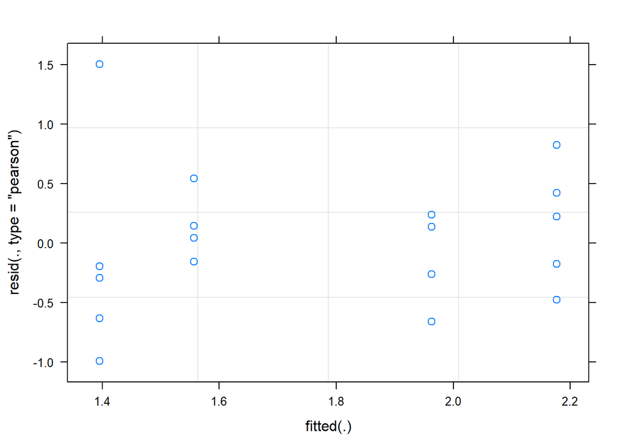

```r
plot(mod2, resid(., type="pearson")~fitted(.))
```

The above corresponds to the default (i.e. plot(mod2)). To split it per researchers,

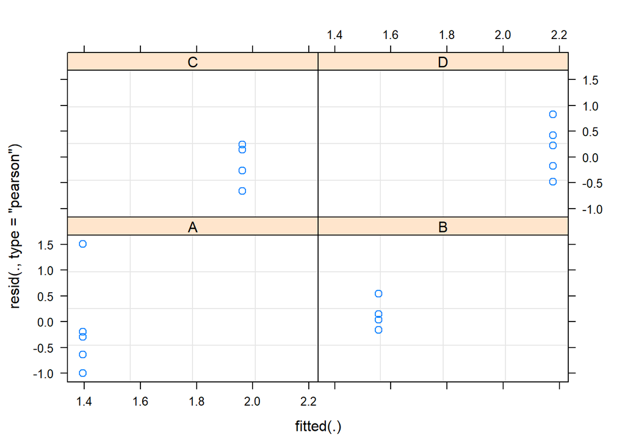

```r
plot(mod2, resid(., type="pearson")~fitted(.) | ID)
```

To check the normality of the residuals using a QQ-plot

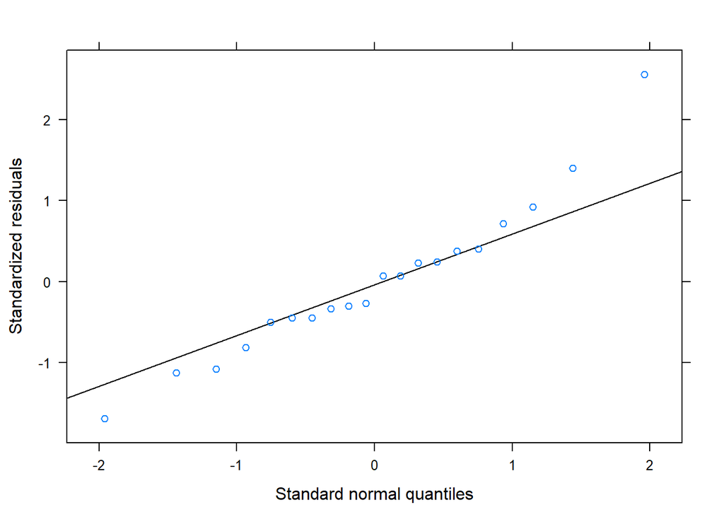

```r
library(lattice)
qqmath(mod2)
```

The id option allow to identify the residuals larger than the normal quantile at level 1-id/2. For example,

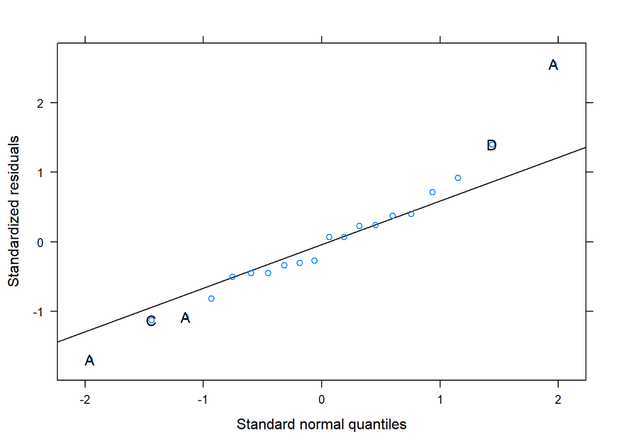

```r
qqmath(mod2, id=0.3)
```

```r
qnorm(p=1-0.3/2)
```

```
## [1] 1.036433
```

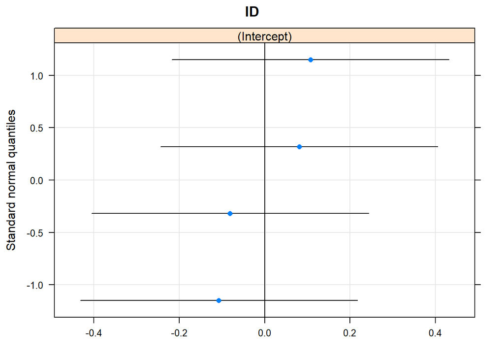

```r
qqmath(ranef(mod2))
```

# References

Baguley, Thom. 2006. “Psychological Statistics: What Is All This Stuff About Sphericity in My Repeated Measures Anova Output?” Webpage. http://psychologicalstatistics.blogspot.ch/2006/05/what-is-all-this-stuff-about.html.

“Introduction to Linear Mixed Models.” 2017. Webpage. UCLA/IDRE. https://stats.idre.ucla.edu/other/mult-pkg/introduction-to-linear-mixed-models/.

Pinheiro, J. C., and D. Bates. 2009. *Mixed-Effects Models in S and S-Plus*. Statistics and Computing. Springer.

Rencher, Alvin C. 2002. *Methods of Multivariate Analysis*. John Wiley & Sons, Inc.

Sahai, Hardeo, and Mohammed I. Ageel. 2000. *The Analysis of Variance: Fixed, Random and Mixed Models*. Birkhäuser Boston.